# ME414 - Estatística para Experimentalistas

## Modelo Binomial

## Modelo Binomial

Ao obtermos uma amostra do experimento/fenômeno aleatório com observações binárias, podemos resumir os resultados usando o número ou a proporção de observações com o resultado de interesse.

Sob certas condições, a v.a. \(X\) que conta o número de vezes que um resultado específico ocorreu, dentre dois possíveis, tem uma distribuição de probabilidade chamada **Binomial**.

- Considere um experimento aleatório com espaço amostral \(\Omega\) e o evento \(A\).
- Vamos dizer que ocorreu sucesso se o evento \(A\) aconteceu. Se \(A\) não aconteceu ocorreu fracasso.
- Repetimos o experimento \(n\) vezes, de forma independente.
- Seja \(X\) o número de sucessos nos \(n\) experimentos.

## Exemplo: vacinas

Sabe-se que a eficiência de uma vacina é de \(80\%\).

Um grupo de 3 indivíduos é sorteado, dentre a população vacinada, e cada um é submetido a testes para averiguar se está imunizado.

Nesse caso, consideramos como sucesso a imunização.

\[ X_i = \begin{cases} 1, & \mbox{indivíduo i está imunizado} \\ 0, & \mbox{caso contrário} \end{cases}\]

Pelo enunciado, sabe-se que \(P(X_{i}=1)=p=0.8\).

## Exemplo: vacinas

- Os indivíduos 1, 2 e 3 são independentes.
- As v.a.’s \(X_1\), \(X_2\) e \(X_3\) são Bernoulli.
- Se o interesse está em estudar \(X=\) número de indivíduos imunizados no grupo, \(X\) poderá assumir valores \(\{0,1,2,3\}\).
- Note que \(X=X_{1}+X_{2}+X_{3}\).

## Exemplo: vacinas

| evento | P(evento) | X |
| --- | --- | --- |
| \(X_{1}=0\), \(X_{2}=0\), \(X_{3}=0\) | \((0.2)^{3}\) | 0 |
| \(X_{1}=1\), \(X_{2}=0\), \(X_{3}=0\) | \(0.8\times(0.2)^{2}\) | 1 |
| \(X_{1}=0\), \(X_{2}=1\), \(X_{3}=0\) | \(0.8\times(0.2)^{2}\) | 1 |
| \(X_{1}=0\), \(X_{2}=0\), \(X_{3}=1\) | \(0.8\times(0.2)^{2}\) | 1 |
| \(X_{1}=1\), \(X_{2}=1\), \(X_{3}=0\) | \((0.8)^{2}\times0.2\) | 2 |
| \(X_{1}=1\), \(X_{2}=0\), \(X_{3}=1\) | \((0.8)^{2}\times0.2\) | 2 |
| \(X_{1}=0\), \(X_{2}=1\), \(X_{3}=1\) | \((0.8)^{2}\times0.2\) | 2 |
| \(X_{1}=1\), \(X_{2}=1\), \(X_{3}=1\) | \((0.8)^{3}\) | 3 |

## Modelo Binomial

Assim, as probabilidades de cada valor possível de \(X\) são:

| \(X\) | 0 | 1 | 2 | 3 |
| --- | --- | --- | --- | --- |
| \(P(X=x)\) | \((0.2)^{3}\) | \(3\times0.8\times(0.2)^{2}\) | \(3\times(0.8)^{2}\times0.2\) | \((0.8)^{3}\) |

O comportamento de \(X\) é completamente determinado pela função:

\[P(X=x)={3\choose x}(0.8)^{x}(0.2)^{3-x}, \qquad x=0,1,2,3.\]

## Binomial

**Modelo Geral:** Considere a repetição de \(n\) ensaios \(X_i\) Bernoulli independentes e todos com a mesma probabilidade de sucesso \(p\).

A variável aleatória \(X=X_{1}+...+X_{n}\) representa o total de sucessos e corresponde ao modelo Binomial com parâmetros \(n\) e \(p\), ou seja, \(X\sim Bin(n,p)\).

A probabilidade de se observar \(x\) é dada pela expressão geral: \[P(X=x)={n\choose x}p^{x}(1-p)^{n-x}, \qquad x=0,1,...,n\]

A esperança e variância de uma v.a. Binomial são dadas por: \[\mathbb E(X)=np \qquad \mbox{e} \qquad Var(X)=np(1-p)\]

## Modelo Binomial

Distribuição de probabilidade de uma \(Bin(3, p)\), com \(p=0.2, 0.5\) e \(0.8\).

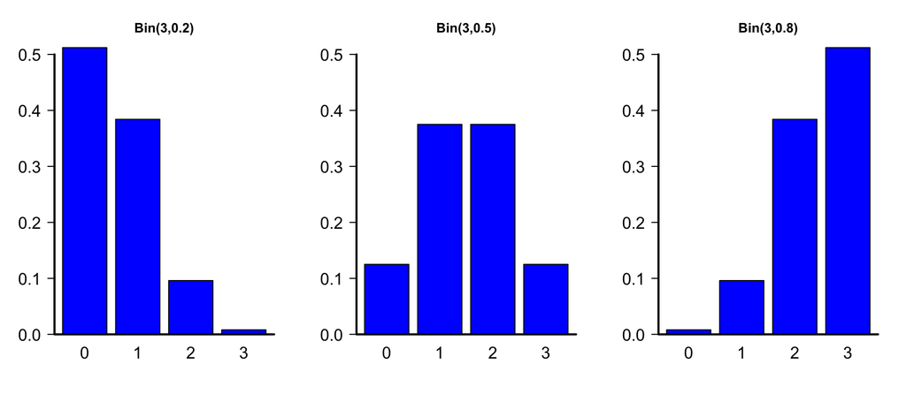

## Modelo Binomial

Distribuição de probabilidade de uma \(Bin(10, p)\), com \(p=0.2, 0.5\) e \(0.8\).

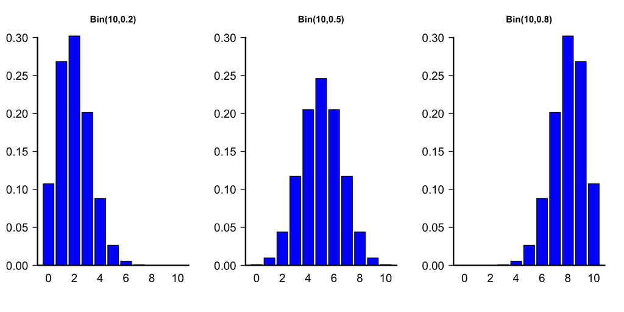

## Exemplo: Vacina

- No exemplo da vacina, temos então que o número de indíviduos imunizados segue uma distribuição Binomial com \(n=3\) e \(p=0.8\)

> \[X\sim Bin(3,0.8)\]
- Qual a probabilidade de que dentre os 3 indíviduos, nenhum tenha sido imunizado? \[ P(X=0) = {3 \choose 0} (0.8)^0 (0.2)^3 = 0.008\]
- Encontre a esperança e variância:

> \[\mathbb E(X)=3\times 0.8 = 2.4 \qquad \mbox{e} \qquad Var(X)=3\times0.8\times0.2 = 0.48\]

## Exemplo: Inspeção

Um inspetor de qualidade extrai uma amostra aleatória de 10 tubos armazenados num depósito onde, de acordo com os padrões de produção, se espera um total de \(20\%\) de tubos defeituosos.

Qual é a probabilidade de que não mais do que \(2\) tubos extraídos sejam defeituosos?

Se \(X\) denotar a variável “número de tubos defeituosos em 10 extrações independentes e aleatórias”, qual o seu valor esperado? Qual a variância?

## Exemplo: Inspeção

Note que a variável aleatória \(X\) = número de tubos defeituosos em 10 extrações tem distribuição binomial, com parâmetros \(n=10\) e \(p=0.2\).

> Então, “não mais do que dois tubos defeituosos” é o evento \(\{X\leq2\}\).

> Sabemos que, para \(X \sim Bin(10, 0.2)\) \[P(X=x) = { 10\choose x } (0.2)^x (0.8)^{10-x}, \qquad x=0,1, \ldots, 10\]

> e que \[\begin{aligned} P(X\leq2) &= P(X=0) + P(X=1) + P(X=2) \\ &=(0.8)^{10} + 10 (0.2)(0.8)^{9} + 45 (0.2)^2 (0.8)^8 = 0.678 \end{aligned}\]

## Exemplo: Inspeção

Se \(X \sim Bin(n,p)\), então \(\mathbb E(X) = np\) e \(Var(X) = np(1-p)\)

> Então:

> \(\mathbb E(X) = 10 (0.2) = 2\)

> \(Var(X) = 10 (0.2)(0.8) = 1.6\)

> Quando se encontram quatro ou mais tubos defeituosos, o processo de produção é interrompido para revisão. Qual é a probabilidade que isto aconteça?

> \[ \begin{aligned} P(X\geq 4) &= 1 - P(X < 4) \\ &= 1 - P(X \leq 3) \\ &= 1-0.879 = 0.121 \end{aligned} \]

## Aproximação da Binomial pela Poisson

## Distribuição de Poisson

- Muitas vezes, em problemas em que seria natural usar a distribuição binomial, temos \(n\) muito grande (\(n\to \infty\)) e \(p\) muito pequeno (\(p\to 0\)).
- Nesses casos, o cálculo fica difícil com calculadoras comuns.
- Considerando uma v.a. \(X\sim\mbox{Bin}(n,p)\), quando temos grandes valores para \(n\) e \(p\) pequeno (mantendo-se o produto \(np=\lambda\) constante), podemos usar a seguinte aproximação para a probabilidade:

\[P(X=x)={\binom{n}{x}}p^{x}(1-p)^{n-x} \approx \frac{e^{-np}(np)^{x}}{x!}\,,\quad x=0,1,2,\ldots n\]

- Geralmente considera-se o critério \(np\leq7\) para usar essa aproximação.
- [Demonstração](http://www.proofwiki.org/wiki/Binomial_Distribution_Approximated_by_Poisson_Distribution)

## Exemplo

\(X\sim Bin(100,0.065)\), deseja-se obter \(P(X=10)\)

- No modelo Binomial: \(P(X=10)= {\binom{100}{10}}(0.065)^{10}(0.935)^{100-10}=0.055\)
- \(\lambda= np =100\times0.065=6.5\leq7\)
- No modelo Poisson: \(P(X=10)=\frac{e^{-6.5}(6.5)^{10}}{10!}\approx0.056\)

## Poisson para Aproximar uma Binomial

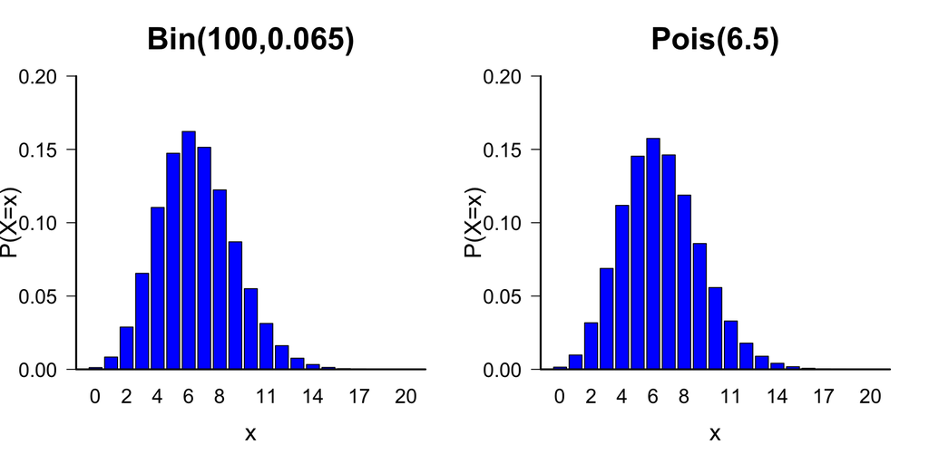

## Exemplo

A probabilidade de uma lâmpada se queimar ao ser ligada é \(1/100\). Numa instalação com 100 lâmpadas, qual a probabilidade de 2 lâmpadas se queimarem ao serem ligadas?

- No modelo Binomial: \(X\sim\mbox{Bin}(100,0.01)\)

\(P(X=2)= {\binom{100}{2}}(0.01)^{2}(0.99)^{100-2}\)=0.1849

- \(\lambda= np =100\times0.01=1\leq7\)
- No modelo Poisson: \(P(X=2)=\frac{e^{-1}(1)^{2}}{2!}\approx0.1839\)

## Distribuição de Poisson

Outro caso em que a distribuição de Poisson é utilizada.

A distribuição de Poisson expressa a probabilidade de um determinado número de eventos ocorrer em um intervalo fixo de tempo ou espaço se esses eventos ocorrerem com uma taxa média constante conhecida. Por exemplo:

- carros que passam por um cruzamento por minuto, durante uma certa hora do dia;
- erros tipográficos por página, em um livro;
- defeitos por unidade (\(m^3\), \(m^2\), \(m\), etc…) por peça fabricada;
- colônias de bactérias numa dada cultura por \(0.01 mm^2\), numa plaqueta de microscópio;
- mortes por ataque de coração por ano, em um certo bairro;
- etc…

## Distribuição de Poisson

Uma variável aleatória \(X\) tem distribuição de Poisson com parâmetro \(\lambda>0\), se sua função de probabilidade é dada por: \[P(X=x)=\frac{e^{-\lambda}\lambda^{x}}{x!}, \qquad x=0,1,2,...\]

- \(\lambda\) é chamado de taxa de ocorrência
- \(\mathbb E(X)=Var(X)=\lambda\)
- Notação: \(X\sim P(\lambda)\)

**Obs.:** \(e\), número de Euler, é base do logaritmo natural (\(e = 2.71828...\)).

A distribuição de Poisson é adequada quando as seguintes condições são atendidas:

- \(x\) representa o número de vezes que um evento ocorre em um intervalo de tempo específico, podendo assumir os valores \(0, 1, 2, ...\).
- A ocorrência de um evento não influencia a probabilidade de ocorrência de um segundo evento, ou seja, os eventos são independentes.
- A taxa média de ocorrência dos eventos é constante e independente de ocorrências passadas.
- Dois eventos não podem acontecer exatamente ao mesmo tempo; em qualquer subintervalo suficientemente pequeno, ocorre no máximo um evento.
- A probabilidade de um evento ocorrer em uma parte do período total é proporcional ao comprimento desse subintervalo.

## Exemplo: Erros em um livro

Num livro de 800 páginas, há 800 erros de impressão. Qual a probabilidade de que uma página contenha pelo menos 3 erros?

\(X =\) número de erros por página

> Taxa de ocorrência: \(\lambda=1\)

\[ \begin{aligned} P(X\geq 3) &= 1-P(X<3)\\ &= 1-[P(X=0)+P(X=1)+P(X=2)]\\ &=1-\left\{ \frac{e^{-1}1^0}{0!} + \frac{e^{-1}1^1}{1!} +\frac{e^{-1}1^2}{2!} \right\}\\ &=0.08 \end{aligned} \]

## Exemplo: Mensagens no Facebook

Uma firma recebe 720 mensagens em sua página do Facebook durante as 8 horas de horário comercial. Qual a probabilidade de que em 6 minutos no horário comercial a firma receba pelo menos 4 mensagens no Facebook?

\[ \begin{aligned} 720\mbox{ mensagens} & \rightarrow 480 \mbox{ min}\\ \lambda &\rightarrow 6 \mbox{ min} \end{aligned} \]

Então, usando “regra de três”, \(\lambda=9\) e

\[ \begin{aligned} P(X\geq 4)&= 1-P(X<4)=1-P(X\leq 3)\\ &= 1-\left[\frac{e^{-9}9^0}{0!}+\frac{e^{-9}9^1}{1!} +\frac{e^{-9}9^2}{2!} +\frac{e^{-9}9^3}{3!} \right]\\ &=0.979 \end{aligned} \]

## Exemplo: SAC

[figure not shown]

Numa central de SAC (serviço de atendimento ao consumidor) chegam 300 telefonemas por hora. Qual a probabilidade de que:

- num minuto não haja nenhuma chamada?
- em 2 minutos haja 2 chamadas?
- em \(t\) minutos não haja chamadas?

## Exemplo: SAC

[figure not shown]

\(X=\) número de chamadas por minuto.

- Taxa de ocorrência por minuto: \(\lambda= 300/60=5\)

\[ P(X= 0)=\frac{e^{-5}5^0}{0!}=0.0067 \]

> \(X=\) número de chamadas a cada 2 minutos.
- Taxa de ocorrência em 2 minutos: \(\lambda= 10\) \[P(X= 2)=\frac{e^{-10}10^2}{2!}=0.00227\]

> \(X=\) número de chamadas a cada \(t\) minutos.
- Taxa de ocorrência em \(t\) minutos: \(\lambda=5t\)

\[P(X=0)=\frac{e^{-5t}(5t)^0}{0!}=e^{-5t}\]

## Exemplo: Twitter

[figure not shown]

O número citações de uma certa conta do Twitter ocorre segundo uma distribuição de Poisson, com a média de oito citações por minuto.

Determinar qual a probabilidade de que num minuto se tenha:

1. dez ou mais citações;
2. menos que nove citações;
3. entre sete (inclusive) e nove (exclusive) citações.

## Exemplo: Twitter

Sabemos que se \(X \sim \mbox{Poisson}(\lambda)\), então sua função de probabilidade é \[P(X=x) = \frac{e^{-\lambda} \lambda^x }{ x!}, \qquad x=0,1,\ldots\]

> Além disso, \(\mathbb{E}(X)=\lambda\).

> O enunciado diz *média de oito citações por minuto*, então a variável aleatória \(X\) = *número de citações por minuto* tem distribuição \(\mbox{Poisson}(8)\).
- A probabilidade de dez ou mais chamadas é dada por:

\[ \begin{aligned} P(X\geq10) & = 1-P(X<10) = 1-P(X\leq9)\\ &= 1-\displaystyle\sum_{k=0}^9 \frac{e^{-8}8^k}{k!} = 1- e^{-8} - \ldots - \displaystyle\frac{e^{-8}8^9}{9!} = 0.2833 \end{aligned}\]

## Exemplo: Twitter

- A probabilidade de termos menos que nove citações em um minuto é dada por:

\[P(X < 9) = P(X \leq 8) = e^{-8} + \ldots + \displaystyle\frac{e^{-8}8^8}{8!} = 0.5926\]

- A probabilidade de termos entre sete (inclusive) e nove (exclusive) citações em um minuto é dada por:

\[ \begin{aligned} P(7\leq X < 9)&=P(7\leq X \leq 8) = P(X=7)+P(X=8)\\ &=\displaystyle\frac{e^{-8}8^7}{7!}+\displaystyle\frac{e^{-8}8^8}{8!} = 0.2792 \end{aligned} \]

## Distribuição Geométrica

## Distribuição Geométrica

Consideremos novamente um experimento aleatório com espaço de resultados \(\Omega\) e o evento \(A\).

Vamos dizer que ocorreu sucesso se o evento \(A\) aconteceu e \(p=P(\mbox{sucesso})\).

Repetimos o experimento até o primeiro sucesso.

Seja \(X\) o número de repetições até o primeiro sucesso.

**Exemplo:** lançar uma moeda repetidas vezes até a primeira cara e \(p=P(cara)\).

Os valores possíveis de \(X\) são \(\{1,2,3,...\}\).

\[ \begin{aligned} P(X=1) &=p && (\mbox{sucesso logo na primeira tentativa})\\ P(X=2) &= (1-p)p && (\mbox{1 fracasso seguido de 1 sucesso})\\ P(X=k) &= (1-p)^{k-1} p && (\mbox{$k-1$ fracassos sucessivos e 1 sucesso}) \end{aligned}\]

## Distribuição Geométrica

**Modelo Geral:** Suponha uma sequência de ensaios de Bernoulli independentes com probabilidade de sucesso \(p\).

> Seja \(X\) a v.a. que representa o número de ensaios de Bernoulli até a ocorrência do primeiro sucesso. Então dizemos que \(X\) segue uma distribuição **Geométrica** com parâmetro \(p\), ou seja, \(X\sim G(p)\).

> A probabilidade de se observar \(x\) é dada por: \[P(X=x)=(1-p)^{x-1}p, \qquad x=1,2,\ldots\]

> A esperança e variância de uma v.a. Geométrica são dadas por: \[\mathbb E(X)= \frac{1}{p} \qquad \mbox{e} \qquad Var(X)=\frac{1-p}{p^2}\]

## Distribuição Geométrica

Distribuição de probabilidade de uma \(G(p)\), com \(p=0.3, 0.5\) e \(0.7\).

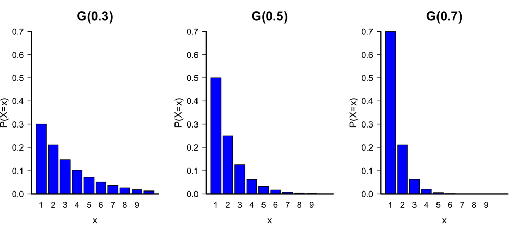

## Distribuição Geométrica

A função de distribuição acumulada de uma v.a. \(G(p)\) é dada por: \[F(x)=P(X\leq x)=1-(1-p)^x\]

A distribuição geométrica tem uma propriedade que serve para caracterizá-la no conjunto das distribuições discretas: a propriedade de perda de memória!

**Propriedade de Perda de Memória**

\[P(X > x+m \mid X > m)=P(X > x)\]

**Interpretação:** O fato de já termos observado \(m\) fracassos sucessivos não muda a probabilidade do número de ensaios até o primeiro sucesso ocorrer.

## Propriedade de perda de memória

\[P(X > x+m \mid X > m)=P(X > x)\]

**Demonstração:**

Lembre-se que: \[F(x)=P(X\leq x)=1-(1-p)^x \quad \Longrightarrow \quad P(X > x)= (1-p)^{x}\]

Então, \[ \begin{aligned} P(X > x+m \mid X > m) &= \frac{P(X > x+m, X> m)}{P(X> m)} \\ & = \frac{P(X > x+m)}{P(X> m)} = \frac{(1-p)^{x+m}}{(1-p)^m} \\ &=(1-p)^{x} = P(X> x) \\ \end{aligned} \]

## Exemplo: Sinal de trânsito

A probabilidade de se encontrar aberto o sinal de trânsito numa esquina é \(0.2\).

Qual a probabilidade de que seja necessário passar pelo local \(5\) vezes para encontrar o sinal aberto pela primeira vez?

\(X=\) número de vezes necessárias para encontrar o sinal aberto.

\(p=P(\mbox{sinal aberto}) = 0.2\)

\[\begin{aligned} P(X=5) &= (1-p)^{4} p \\ &= 0.8^4\times 0.2 \\ &= 0.0819 \end{aligned} \]

## Exemplo: Banco de Sangue

Um banco de sangue necessita sangue do tipo O negativo. Suponha que a probabilidade de uma pessoa ter este tipo de sangue seja \(0.10\). Doadores permanentes chegam ao hemocentro para fazer sua doação rotineira. Calcule a probabilidade de que o primeiro doador com sangue do tipo O negativo seja:

- o primeiro a chegar;
- o segundo;
- o sétimo.
- Quantos doadores esperamos passar pelo hospital até encontrarmos um com sangue O negativo?

> **Fonte:** Prof. Mario Gneri, Notas de Aula.

## Exemplo: Banco de Sangue

Seja \(X\) o número de doadores que chegam no hemocentro até a chegada do primeiro doador com sangue O negativo.

Novamente temos um experimento com distribuição geométrica. Usando a fórmula para a função de probabilidade, send \(X \sim G(0.1)\):

\[P(X=x) = 0.9^{x-1} 0.1, \qquad x=1,2,\ldots \]

Temos que

- \(P(X=1) = 0.1\)
- \(P(X=2) = 0.9 \times 0.1 = 0.09\)
- \(P(X=7) = 0.9^6 \times 0.1 = 0.053\)
- \(\mathbb E(X) = 1/0.1=10.\) Neste caso, esperamos que dez doadores passem pelo hospital, em média, para encontrarmos o primeiro com sangue O negativo.

## Hipergeométrica

## Distribuição Hipergeométrica

- População dividida em duas características
- Extrações casuais sem reposição

> **Detalhes:**
- \(N\) objetos
- \(r\) têm a característica A
- \(N-r\) têm a característica B
- um grupo de \(n\) elementos é escolhido ao acaso, dentre os \(N\) possíveis, sem reposição.

> **Objetivo:** calcular a probabilidade de que este grupo de \(n\) elementos contenha \(x\) elementos com a característica A.

## Distribuição Hipergeométrica

> Seja \(X\) a v.a. que representa o número de elementos com a característica A dentre os \(n\) selecionados.

> Então dizemos que \(X\) segue uma distribuição **Hipergeométrica** com parâmetros \(N,n,r\), ou seja, \(X \sim Hip(N,n,r)\).

> A probabilidade de se observar \(x\) é dada por: \[P(X=x)=\frac{\binom{r}{x}\binom{N-r}{n-x}}{\binom{N}{n}}, \qquad 0\leq x \leq min\{r,n\}\]

> A esperança e variância são, respectivamente:

\[\mathbb E(X)=\frac{nr}{N} \qquad \mbox{e} \qquad Var(X)=\frac{nr}{N}\left(1-\frac{r}{N}\right)\frac{(N-n)}{(N-1)}\]

## Exemplo: Urna

Uma urna contém 10 bolas: 6 brancas e 4 pretas.

> Qual a probabilidade de obter 3 bolas brancas dentre 4 bolas retiradas?

> Seja \(X\) o número de bolas brancas dentre as 4 bolas retiradas

> Então, \(X\sim Hip(N=10, n=4, r=6)\) e

\[P(X=x)=\frac{\binom{r}{x}\binom{N-r}{n-x}}{\binom{N}{n}}, \qquad 0\leq x \leq min\{r,n\}\]

> Portanto,

\[P(X=3)=\frac{\binom{6}{3}\binom{4}{1}}{\binom{10}{4}}=\frac{8}{21}\]

## Exemplo: Mega-Sena

Qual a probabilidade de um jogador ganhar na Mega-Sena jogando 6 dezenas?

- \(N=60\) (dezenas de 01 a 60)
- \(n=6\) (dezenas sorteadas)
- \(r=6\) (dezenas escolhidas pelo jogador)
- \(x=6\) (número de sucessos, queremos 6)

> Então, a probabilidade de ganhar na Mega-Sena é:

> \[P(X=6)=\frac{\binom{6}{6}\binom{54}{0}}{\binom{60}{6}}=\frac{1}{50063860}\]

## Aplicação: Controle de Qualidade

Suponha um lote com \(N=100\) elementos a ser analisado.

São escolhidas \(n=5\) peças sem reposição.

Sabendo que neste lote de 100 elementos, \(r=10\) são defeituosos.

Se \(X\) é o número de peças defeituosas em 5 escolhidas, então \[X\sim Hip(N=100, n=5, r=10)\]

A probabilidade de nenhuma peça defeituosa na amostra retirada é:

\[P(X=0)= \frac{\binom{10}{0}\binom{100-10}{5-0}}{\binom{100}{5}}= \frac{\binom{90}{5}}{\binom{100}{5}}\approx0.584\]

## Aplicação: Controle de Qualidade

A probabilidade de pelo menos uma peça defeituosa é:

\[P(X \geq 1) = \sum_{i=1}^{5}P(X=i)= 1-P(X=0)\approx0.416\]